# Terminal Configuration

Mona Zhu

## Overview

```r
# load libraries
library(aspace)
library(car)
library(plyr)
library(reshape2)
library(ggplot2)
library(ggdendro)
library(dendextend)
library(stats)
library(cluster)
library(mclust)
```

This project was a study of a clustering problem. Each individual is asked to search within a task space, where some objects frequently occur next to one another, but rarely with others (in other words, there are “categories” inherent within the structure of the space). As individuals perform the search task, they are also able to freely move around the objects and organize them. The current project aims to group individuals with similar organizational patterns with one another.

```r
raw<-read.table("C:/Users/Grayden Solman/Desktop/Mona/Terminal Configuration/temrinalHulls.txt", sep="\t", header=T)

#### Data cleaning ####

# remove number of suj and items
raw<-raw[complete.cases(raw),]
raw$Suj<-factor(rep(1:51, each=64))
# reorder data frame
raw<-raw[c(4,1:3)]
raw$Target<-factor(ifelse(raw$Cat==4, "Non-Target", "Target"))

target<-subset(raw, Target=="Target")
target$Cat<-factor(target$Cat)
```

Since each configuration is presented as coordinates, we need a way to differentiate between the different qualities of how individuals organize. For instance, some may place the different categories of objects further apart from one another, while other may choose to place them together in one location, etc.

One way to capture these qualities is to look at the central tendency (i.e., center of mass) of each category of objects, as well as the spread among the different objects (i.e, area of the standard distance deviation)

```r
#### Getting centrographic stats for target items ####
sdd<-NULL
sdd.overall<-NULL
for(id in levels(target$Suj)){ # subset by Year
  sub<-target[target$Suj==id,]
  targ.coord<-sub[c(2:3)]
  c.stat.overall<-calc_sdd(id=id, filename="Output.txt",
                    centre.xy=NULL, calccentre=TRUE,
                    weighted=FALSE, weights=NULL, points=targ.coord, verbose=FALSE)
  sdd.overall<-rbind(sdd.overall, c.stat.overall)
  for(c in levels(sub$Cat)){ # subset by time
    coord<-sub[sub$Cat==c,][c(2,3)]
    c.stat<-calc_sdd(id=paste0(id, "_", c), filename="Output.txt",
                    centre.xy=NULL, calccentre=TRUE,
                    weighted=FALSE, weights=NULL, points=coord, verbose=FALSE)
    sdd<-rbind(sdd, c.stat)
  }
}

sdd<-cbind(sdd, strcapture("(.*)_(.*)", as.character(sdd$id), data.frame(Suj="", Cat="")))
names(sdd.overall)[1]<-"Suj"

comb<-merge(sdd.overall, sdd, by="Suj")[-c(2,3,8:10)]
names(comb)[c(2:9)]<-c("Targ.x", "Targ.y", "Targ.r", "Targ.area", "Group.x", "Group.y", "Group.r", "Group.area")

# "Targ.xxx" refers to the centrographic stats related to all target items
# "Group.xxx" refers to the centrographic stats for each individual group of targets (i.e., a subset of the target items)

#### Getting centrographic stats for non-target items ####
nontarg<-subset(raw, Target=="Non-Target")

sdd.ntarg<-NULL
for(id in levels(nontarg$Suj)){ # subset by Year
  sub<-nontarg[nontarg$Suj==id,]
  ntarg.coord<-sub[c(2:3)]
  c.stat.ntarg<-calc_sdd(id=id, filename="Output.txt",
                    centre.xy=NULL, calccentre=TRUE,
                    weighted=FALSE, weights=NULL, points=ntarg.coord, verbose=FALSE)
  sdd.ntarg<-rbind(sdd.ntarg, c.stat.ntarg)
}

names(sdd.ntarg)[1]<-"Suj"

merged<-merge(comb, sdd.ntarg, by="Suj") [-c(11, 12)]
names(merged)[c(11:14)]<-c("NTarg.x", "NTarg.y", "NTarg.r", "NTarg.area")
# "Targ.xxx" refers to the centrographic stats related to all target items
# "Group.xxx" refers to the centrographic stats for each individual group of targets (i.e., a subset of the target items)
all<-merged[c(1, 10, 2:9, 11:14)]
write.csv(all, "Terminal Configuration_Summary_15Feb2019.csv", row.names=F)
```

## First Attempt: Model-Based Clustering

In looking at the pictures of the terminal configuration, several factors stood out as being potentially important for identifying individual differences:

1. whether target categories overlapped or not:

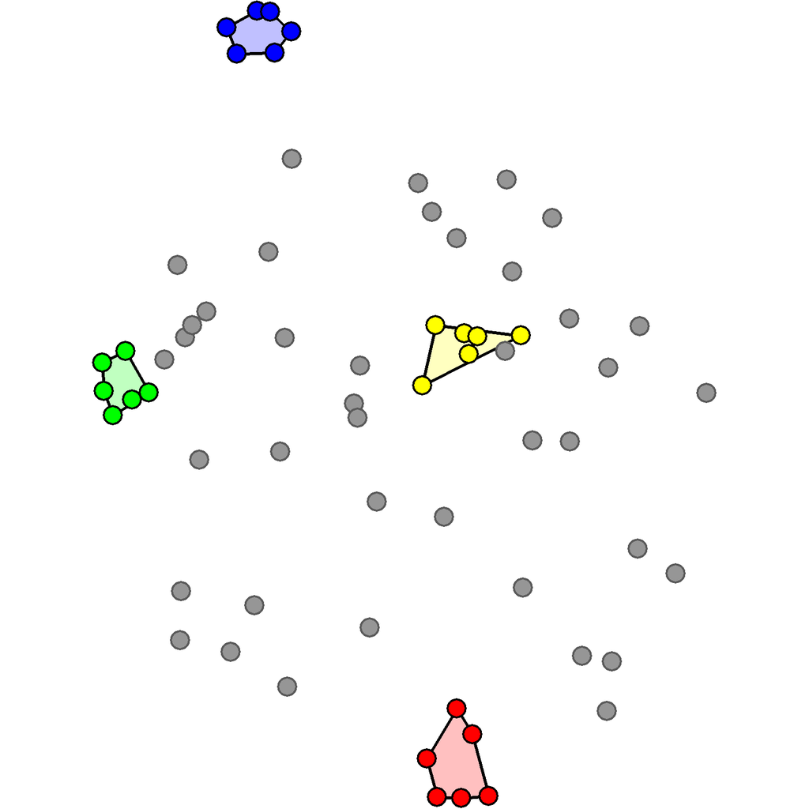

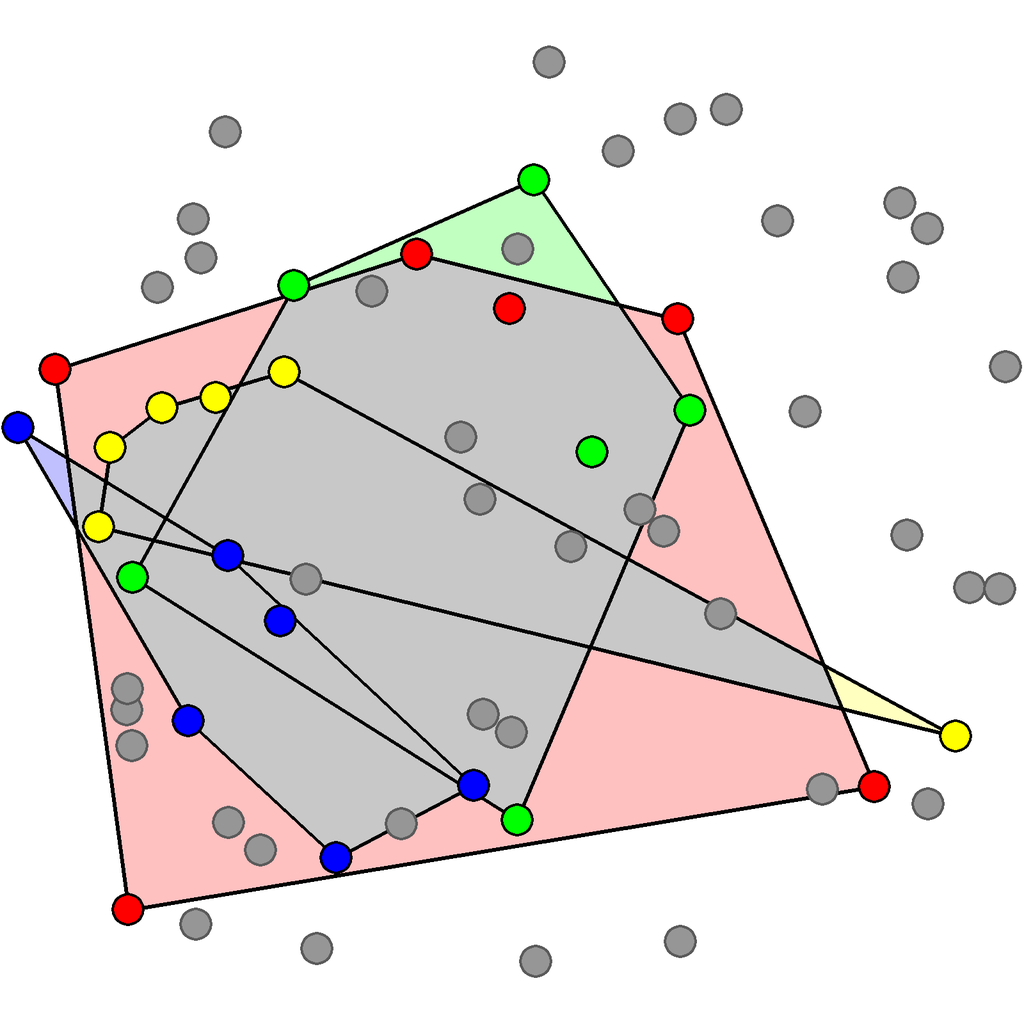

```r
knitr::include_graphics(c("C:/Users/Grayden Solman/Desktop/Mona/Terminal Configuration/Pictures/sub45_terminal249.png", "C:/Users/Grayden Solman/Desktop/Mona/Terminal Configuration/Pictures/sub18_terminal249.png"))
```

2. whether there was overall organization between target and nontarget items despite there being overlap across different target categories

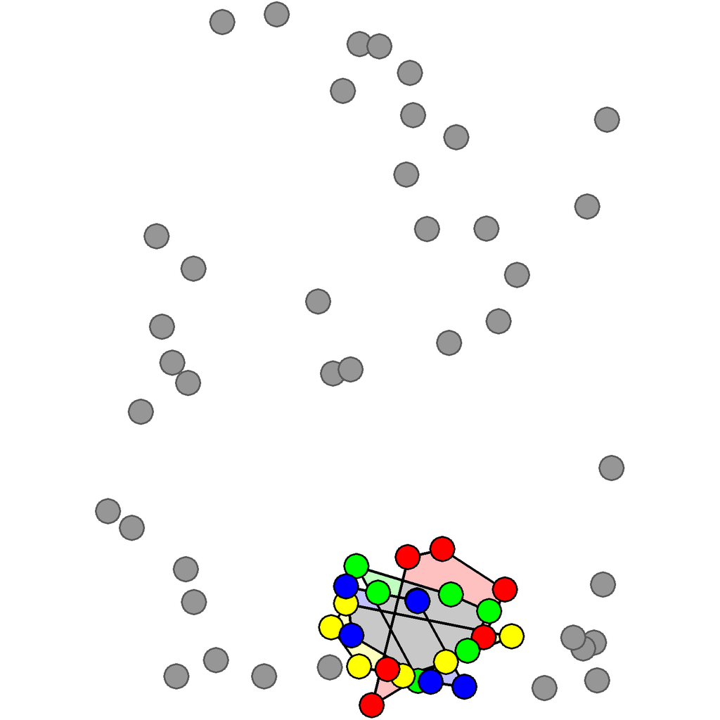

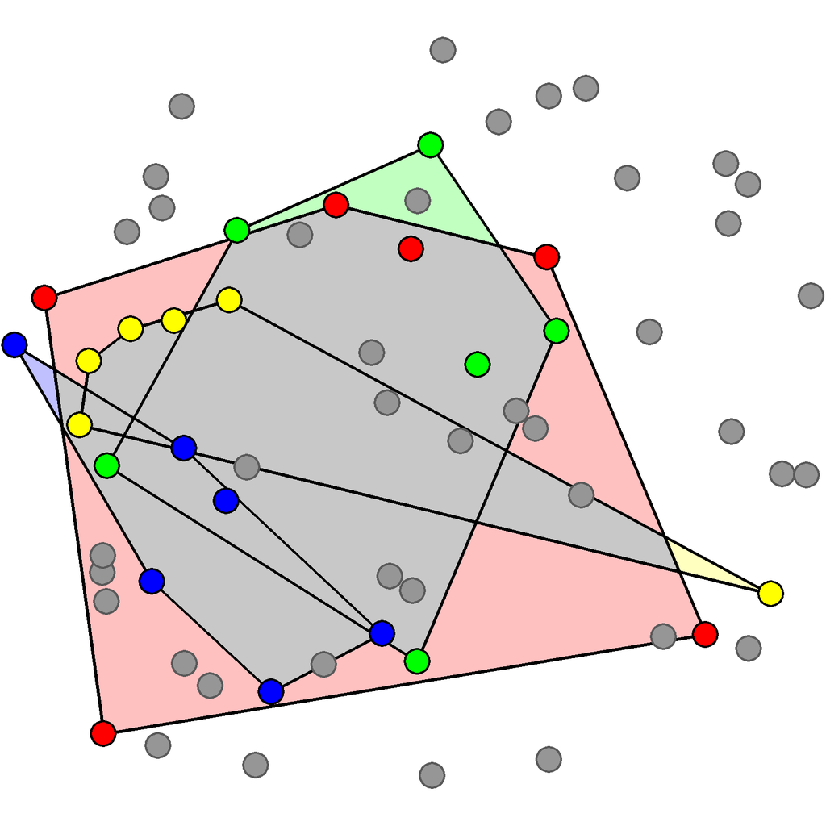

```r
knitr::include_graphics(c("C:/Users/Grayden Solman/Desktop/Mona/Terminal Configuration/Pictures/sub02_terminal249.png", "C:/Users/Grayden Solman/Desktop/Mona/Terminal Configuration/Pictures/sub18_terminal249.png"))
```

I wanted to see based on these characteristics alone, how many clusters would be formed

1. **Dist**: the mean Euclidean distance between the center of mass for all target items and each target category
2. **TargOverlap**: the mean area of overlap between each category of targets and overall target location
3. **Overlap**: the overlap between target and non-target items

```r
all<-read.csv("Terminal Configuration_Summary_15Feb2019.csv")
all$Dist<-sqrt((all$Targ.x-all$Group.x)^2+(all$Targ.y-all$Group.y)^2)
all$TargOverlap<-all$Group.area/all$Targ.area
all$Overlap<-all$Targ.area/all$NTarg.area

sum<-ddply(all, .(Suj), summarise,
           Dist.mean=mean(Dist, na.rm=T),
           TargOverlap.mean=mean(TargOverlap, na.rm=T),
           Overlap.mean=mean(Overlap, na.rm = T))
```

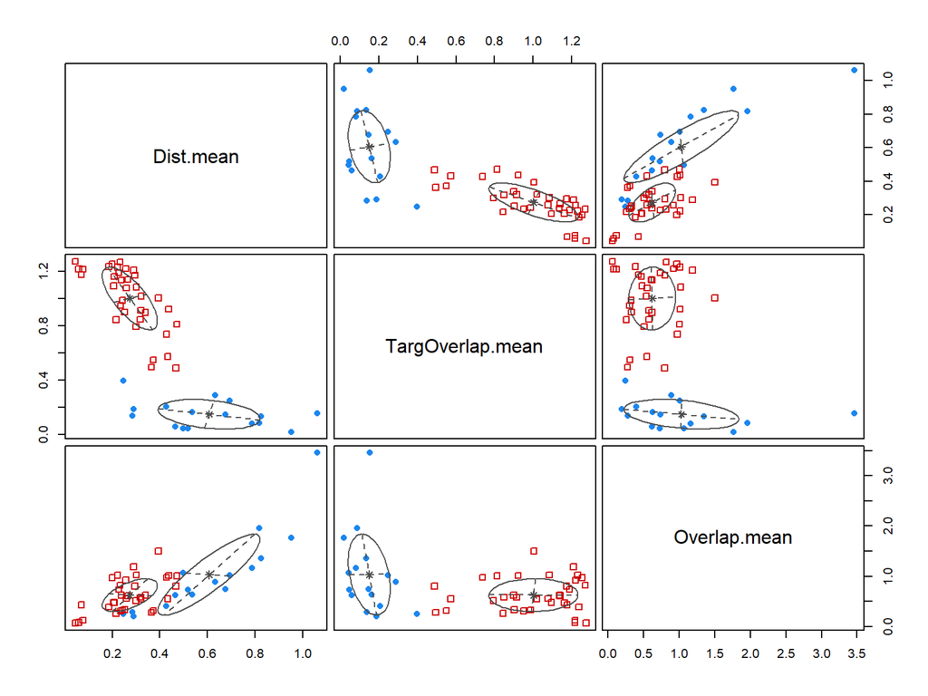

```r
mcluster<-Mclust(sum[c(2:4)])
plot(mcluster, what="classification")
```

This model-based approach produced 2 general clusters – these clusters are pretty fuzzy, given that the scores per individual is an average score.

## Attempt 2: Hierarchical Clustering

In order to get a more fine grain picture of the individual differences, it’s important to take into account the position/spread of each category of objects (or their relation to one another). One way to construct a more fine-grain picture of the categories is to take into account (1) the size of each cluster as well as (2) how far each set of items were from one another. Given that there are 4 distinct sets of objects, this would result in 4 measures of area (for each of the 4 categories of objects) as well as 6 sets of distances between the center of each pairs of categories.

```r
all<-read.csv("Terminal Configuration_Summary_15Feb2019.csv")
all$Cat<-factor(recode(all$Cat, "0='1'; 1='2'; 2='3';3='4'"))

all$Area.s<-scale(log(all$Group.area))

all.melt<-melt(all[c(1,2,15)], id=c(1:2))
all.cast<-dcast(all.melt, Suj~Cat, mean)
names(all.cast)<-c("Suj", "Area1", "Area2", "Area3", "Area4")
a<-all.cast

dist<-NULL
for (id in unique(all$Suj)){
  sub<-subset(all, all$Suj==id)[c(1,2,7,8)]
  for (i in levels(sub$Cat)){
    sub[ ,i]<-sqrt((sub$Group.x - sub$Group.x[sub$Cat==i])^2+(sub$Group.y-sub$Group.y[sub$Cat==i])^2)
    sub[sub==0]<-NA
    dist.melt<-melt(sub, id=c(1:4))
    dist.melt$pairs
  }
  dist<-rbind(dist, sub)
}

dist.melt<-melt(dist, id=c(1:4))
dist.melt<-dist.melt[complete.cases(dist.melt),]
dist.melt$Pairs<-paste0(dist.melt$Cat, "_", dist.melt$variable)
dist.f<-subset(dist.melt, !(dist.melt$Pairs=="1_2"|dist.melt$Pairs=="1_3"|
                           dist.melt$Pairs=="1_4"|dist.melt$Pairs=="2_3"|
                           dist.melt$Pairs=="2_4"|dist.melt$Pairs=="3_4"))
dist.f2<-transform(dist.f, value=scale(sqrt(dist.f$value)))

dist.cast<-dcast(dist.f2, Suj~Pairs, mean)
names(dist.cast)<-c("Suj", "Dist12", "Dist13", "Dist23", "Dist14", "Dist24", "Dist34")
d<-dist.cast[c(1,2,4,7,3,6,5)]

orig<-merge(a, d, by="Suj")
```

The next step is to measure the similar (or dissimilarity) between individuals. Since the assignment of categories is rather arbitrary (e.g., we don’t care about whether category 1 is bitter than category 2 for all individuals; rather, we care that one category was smaller than the other), we need to create permutations in order to make sure we assign each pairs of individuals the smallest dissimilarity score possible.

```r
# create permutations of area/distance pair configurations for each participant
perm<-list()
for (i in unique(d$Suj)){
  data<-data.frame(i, rbind(
c(a[i, 2],a[i, 3],a[i, 4],a[i, 5],d[i, 2],d[i, 3],d[i, 4],d[i, 5],d[i, 6],d[i, 7]),
c(a[i, 2],a[i, 4],a[i, 3],a[i, 5],d[i, 5],d[i, 7],d[i, 6],d[i, 2],d[i, 4],d[i, 7]),
c(a[i, 2],a[i, 4],a[i, 5],a[i, 3],d[i, 5],d[i, 4],d[i, 7],d[i, 7],d[i, 7],d[i, 2]),
c(a[i, 2],a[i, 5],a[i, 4],a[i, 3],d[i, 5],d[i, 7],d[i, 7],d[i, 5],d[i, 7],d[i, 2]),
c(a[i, 2],a[i, 3],a[i, 5],a[i, 4],d[i, 2],d[i, 6],d[i, 7],d[i, 7],d[i, 3],d[i, 5]),
c(a[i, 2],a[i, 5],a[i, 3],a[i, 4],d[i, 7],d[i, 7],d[i, 3],d[i, 2],d[i, 7],d[i, 5]),
c(a[i, 3],a[i, 2],a[i, 4],a[i, 5],d[i, 7],d[i, 5],d[i, 4],d[i, 3],d[i, 7],d[i, 6]),
c(a[i, 3],a[i, 2],a[i, 5],a[i, 4],d[i, 7],d[i, 7],d[i, 7],d[i, 6],d[i, 5],d[i, 3]),
c(a[i, 3],a[i, 4],a[i, 2],a[i, 5],d[i, 3],d[i, 7],d[i, 7],d[i, 7],d[i, 4],d[i, 6]),
c(a[i, 3],a[i, 4],a[i, 5],a[i, 2],d[i, 3],d[i, 4],d[i, 7],d[i, 6],d[i, 7],d[i, 7]),
c(a[i, 3],a[i, 5],a[i, 2],a[i, 4],d[i, 6],d[i, 7],d[i, 5],d[i, 7],d[i, 7],d[i, 3]),
c(a[i, 3],a[i, 5],a[i, 4],a[i, 2],d[i, 6],d[i, 7],d[i, 7],d[i, 3],d[i, 7],d[i, 7]),
c(a[i, 4],a[i, 2],a[i, 3],a[i, 5],d[i, 7],d[i, 2],d[i, 6],d[i, 7],d[i, 7],d[i, 4]),
c(a[i, 4],a[i, 2],a[i, 5],a[i, 3],d[i, 7],d[i, 7],d[i, 7],d[i, 4],d[i, 2],d[i, 7]),
c(a[i, 4],a[i, 3],a[i, 2],a[i, 5],d[i, 7],d[i, 7],d[i, 7],d[i, 7],d[i, 6],d[i, 4]),
c(a[i, 4],a[i, 3],a[i, 5],a[i, 2],d[i, 7],d[i, 6],d[i, 7],d[i, 4],d[i, 7],d[i, 7]),
c(a[i, 4],a[i, 5],a[i, 2],a[i, 3],d[i, 4],d[i, 7],d[i, 2],d[i, 7],d[i, 7],d[i, 7]),
c(a[i, 4],a[i, 5],a[i, 3],a[i, 2],d[i, 4],d[i, 7],d[i, 7],d[i, 7],d[i, 7],d[i, 7]),
c(a[i, 5],a[i, 2],a[i, 3],a[i, 4],d[i, 7],d[i, 2],d[i, 3],d[i, 7],d[i, 5],d[i, 7]),
c(a[i, 5],a[i, 2],a[i, 4],a[i, 3],d[i, 7],d[i, 5],d[i, 7],d[i, 7],d[i, 2],d[i, 7]),
c(a[i, 5],a[i, 3],a[i, 2],a[i, 4],d[i, 7],d[i, 7],d[i, 5],d[i, 7],d[i, 3],d[i, 7]),
c(a[i, 5],a[i, 3],a[i, 4],a[i, 2],d[i, 7],d[i, 3],d[i, 7],d[i, 7],d[i, 7],d[i, 7]),
c(a[i, 5],a[i, 4],a[i, 3],a[i, 2],d[i, 7],d[i, 7],d[i, 7],d[i, 7],d[i, 7],d[i, 7]),
c(a[i, 5],a[i, 4],a[i, 2],a[i, 3],d[i, 7],d[i, 7],d[i, 2],d[i, 7],d[i, 7],d[i, 7])
))
  names(data)<-c("Suj", "Area1", "Area2", "Area3", "Area4",
                          "Pair1", "Pair2", "Pair3", "Pair4", "Pair5", "Pair6")
  perm[[i]]<-data
}
names(perm)<-unique(d$Suj)
```

Once we have created all possible permutations per subject, the next step is to compare the scores between every pair of individuals to get a matrix of dissimilarity scores. Dissimilarity here is calculated using Euclidean distance.

```r
df<-data.frame()
for (i in 1:51){
  for (j in 1:51){
    euc1<-apply(perm[[j]][,-1], 1, function(x) sqrt(sum((x-orig[i,-1])^2)))
    euc2<-apply(perm[[i]][,-1], 1, function(x) sqrt(sum((x-orig[j,-1])^2)))
    euc<-c(euc1, euc2)
    # "1" in the function meant to apply it to every row
    df[i,j]<-min(euc)
    # df2<-df[1:i, i]<-NA
  }
}

dist_mat<-as.dist(df)
```

Next, we created a hierarchical cluster wherein two pairs clusters (could be any size) form a node if they meet a given minimum. For the current hierarchical cluster, the criteria is that the average distance between all points within 2 clusters is a minimum.

A visual representation of the distance/dissimilarity in the matrix.

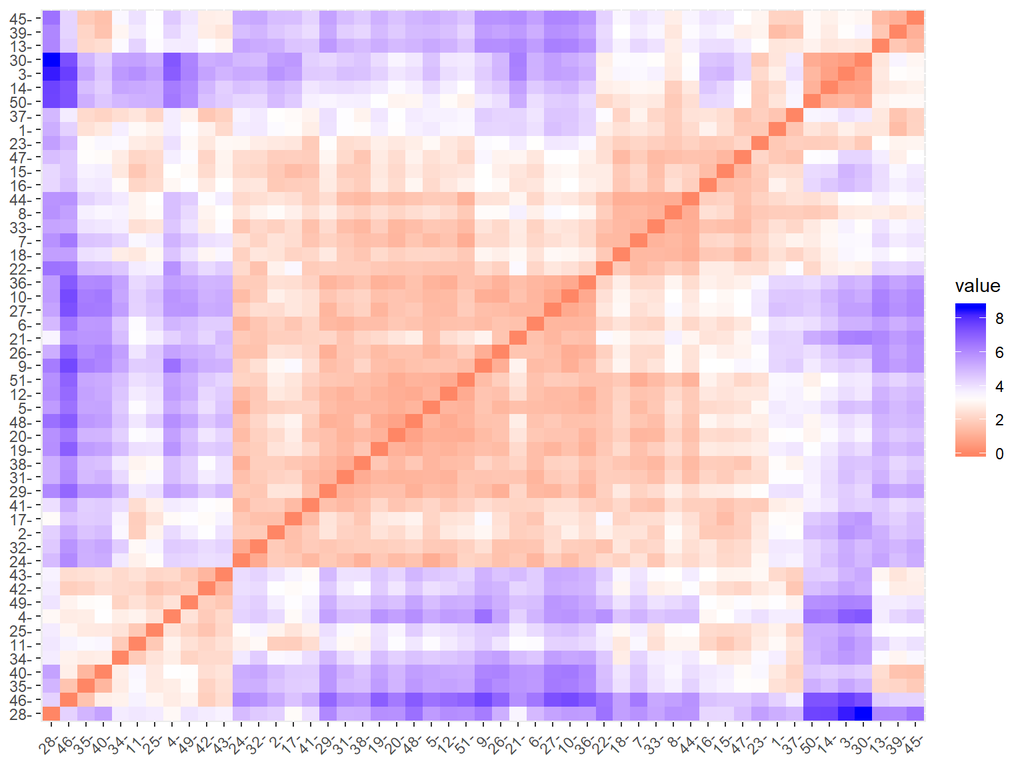

```r
factoextra::fviz_dist(dist_mat ,
   gradient = list(low = "red", mid = "white", high = "blue"))
```

Here is a dendrogram/tree of the hierarchical cluster.

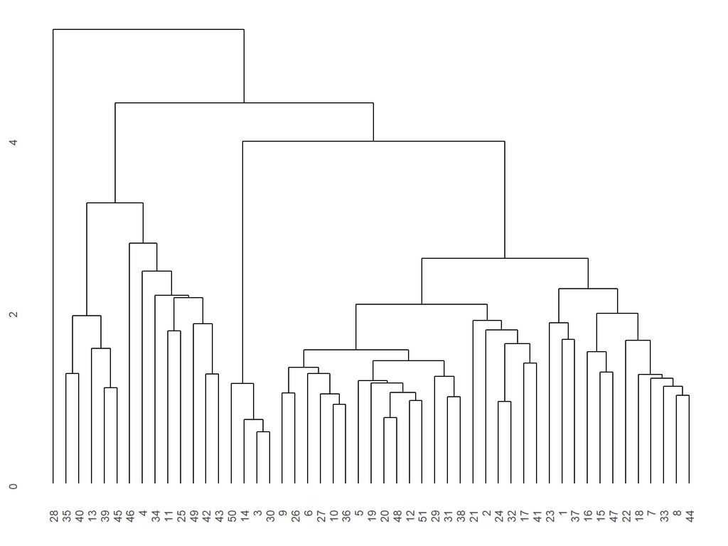

```r
clust1<-hclust(dist_mat, method="average")
ggdendrogram(clust1)
```

### Determining Optimal Number of Clusters

Although we have produced a structure of the hierarchical cluster, we still need to figure out what actually is the optimatl number of clusters. That is, at what point are clusters considered “distinct enough” from one another?

#### Determining the optimal number of clusters

```r
NbClust::NbClust(data=NULL, diss=dist_mat, distance=NULL, min.nc=2, max.nc=15, method="average", index="silhouette")
```

```
##
##  Only frey, mcclain, cindex, sihouette and dunn can be computed. To compute the other indices, data matrix is needed
```

```
## $All.index
##      2      3      4      5      6      7      8      9     10     11
## 0.3585 0.3829 0.3737 0.3822 0.3714 0.3147 0.3285 0.2924 0.2996 0.3034
##     12     13     14     15
## 0.3022 0.2953 0.2981 0.2915
##
## $Best.nc
## Number_clusters     Value_Index
##          3.0000          0.3829
##
## $Best.partition
##  1  2  3  4  5  6  7  8  9 10 11 12 13 14 15 16 17 18 19 20 21 22 23 24 25
##  1  1  1  2  1  1  1  1  1  1  2  1  2  1  1  1  1  1  1  1  1  1  1  1  2
## 26 27 28 29 30 31 32 33 34 35 36 37 38 39 40 41 42 43 44 45 46 47 48 49 50
##  1  1  3  1  1  1  1  1  2  2  1  1  1  2  2  1  2  2  1  2  2  1  1  2  1
## 51
##  1
```

#### Determining Maximum Number of Distinct Clusters

```r
k=15
method="average"
clust<-hclust(dist_mat, method=method)

summ<-matrix(ncol = 2, nrow=k-1)
for (i in 2:k){
  cut<-cutree(clust, i)
  sil_cl <- silhouette(cut ,dist_mat)
  sum.sil_cl<-summary(sil_cl)$ clus.avg.widths

  better<-NULL
  for (j in 1:10000){
    cut.rand<-sample(cut)
    names(cut.rand)<-c(1:51)
    sil.wid<-summary(silhouette(cut.rand ,dist_mat))$clus.avg.widths
    compare<-unname(ifelse(sil.wid>sum.sil_cl, 1, 0))
    better<-rbind(better, compare)
  }
  summ[i-1,1]<-i
  summ[i-1,2]<-ifelse(any(colMeans(better)>0.05), "Yes", "No")
}

summ<-as.data.frame(summ)
names(summ)<-c("Clusters", "SimulatiedBetter?")
summ
```

```
##    Clusters SimulatiedBetter?
## 1         2                No
## 2         3                No
## 3         4                No
## 4         5                No
## 5         6                No
## 6         7                No
## 7         8                No
## 8         9                No
## 9        10                No
## 10       11               Yes
## 11       12               Yes
## 12       13               Yes
## 13       14               Yes
## 14       15               Yes
```

Based on Monte Carlo simulation, there seems to be 10 distinct clusters

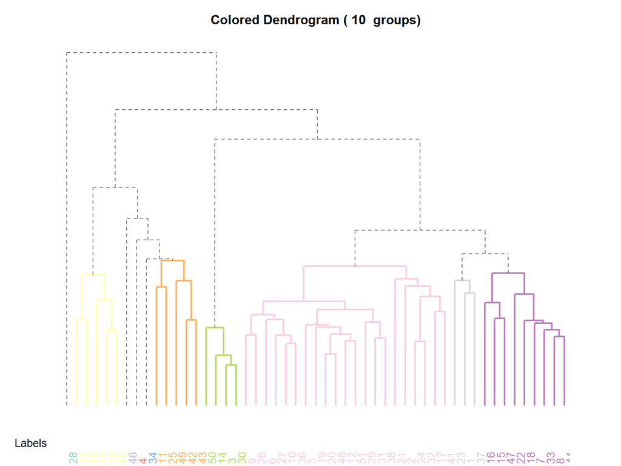

```r
source("http://addictedtor.free.fr/packages/A2R/lastVersion/R/code.R")

clusters=10

# colored dendrogram
op = par(bg = "white")
A2Rplot(clust, k = clusters, boxes = FALSE, col.up = "gray50",
        col.down = RColorBrewer::brewer.pal(clusters, "Set3"))
```

### Cluster Structure

One way to assess the quality of a hierarchical cluster is to look at the agglomerative coefficient (AC). AC ranges between 0 to 1, with higher scores being indicative of stronger cluster structures.

```r
coef.hclust(clust1)
```

```
## [1] 0.7376607
```

We can run the same hierarchical clusters using different methods and see if any one of them produces a better AC score than the average linkage method

```r
m <- c("ward.D2", "single", "complete", "average", "mcquitty")
ac <- function(x) {
  coef.hclust(hclust(dist_mat, method = x))
}

Coef<-NULL
for (i in 1:length(m)){
  AC<-ac(m[i])
  Coef<-c(Coef, AC)
}

names(Coef)<-m
Coef
```

```
##   ward.D2    single  complete   average  mcquitty
## 0.9078034 0.6026053 0.8383009 0.7376607 0.7597509
```

Ward’s method seems to produce the dendrogram with the strongest cluster structure. This method minimizes the the total within-cluster variance by minimizing the error sum of squares. Below is a dendrogram of the hierarchical cluster produced.

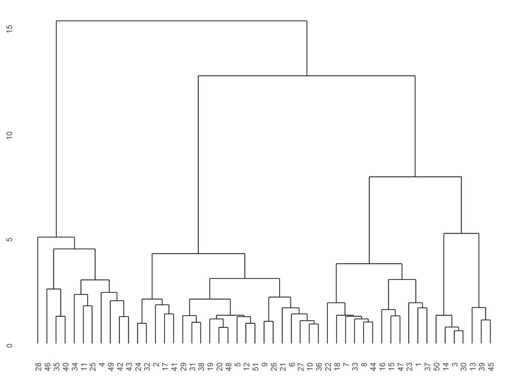

```r
clust1.w<-hclust(dist_mat, method="ward.D2")
ggdendrogram(clust1.w)
```

#### Determining the optimal number of clusters

```r
NbClust::NbClust(data=NULL, diss=dist_mat, distance=NULL, min.nc=2, max.nc=15, method="ward.D2", index="silhouette")
```

```
##
##  Only frey, mcclain, cindex, sihouette and dunn can be computed. To compute the other indices, data matrix is needed
```

```
## $All.index
##      2      3      4      5      6      7      8      9     10     11
## 0.3599 0.3076 0.2730 0.2745 0.2945 0.2993 0.2538 0.2539 0.2236 0.2194
##     12     13     14     15
## 0.2160 0.2322 0.2486 0.2691
##
## $Best.nc
## Number_clusters     Value_Index
##          2.0000          0.3599
##
## $Best.partition
##  1  2  3  4  5  6  7  8  9 10 11 12 13 14 15 16 17 18 19 20 21 22 23 24 25
##  1  1  1  2  1  1  1  1  1  1  2  1  1  1  1  1  1  1  1  1  1  1  1  1  2
## 26 27 28 29 30 31 32 33 34 35 36 37 38 39 40 41 42 43 44 45 46 47 48 49 50
##  1  1  2  1  1  1  1  1  2  2  1  1  1  1  2  1  2  2  1  1  2  1  1  2  1
## 51
##  1
```

#### Determining Maximum Number of Distinct Clusters

```r
k=15
method="ward.D2"
clust2<-hclust(dist_mat, method=method)

summ<-matrix(ncol = 2, nrow=k-1)
for (i in 2:k){
  cut<-cutree(clust2, i)
  sil_cl <- silhouette(cut ,dist_mat)
  sum.sil_cl<-summary(sil_cl)$ clus.avg.widths

  better<-NULL
  for (j in 1:10000){
    cut.rand<-sample(cut)
    names(cut.rand)<-c(1:51)
    sil.wid<-summary(silhouette(cut.rand ,dist_mat))$clus.avg.widths
    compare<-unname(ifelse(sil.wid>sum.sil_cl, 1, 0))
    better<-rbind(better, compare)
  }
  summ[i-1,1]<-i
  summ[i-1,2]<-ifelse(any(colMeans(better)>0.05), "Yes", "No")
}

summ<-as.data.frame(summ)
names(summ)<-c("Clusters", "SimulatiedBetter?")
summ
```

```
##    Clusters SimulatiedBetter?
## 1         2                No
## 2         3                No
## 3         4                No
## 4         5                No
## 5         6                No
## 6         7               Yes
## 7         8               Yes
## 8         9               Yes
## 9        10               Yes
## 10       11               Yes
## 11       12               Yes
## 12       13               Yes
## 13       14                No
## 14       15               Yes
```

Based on Monte Carlo simulation, there seems to be 6 distinct clusters

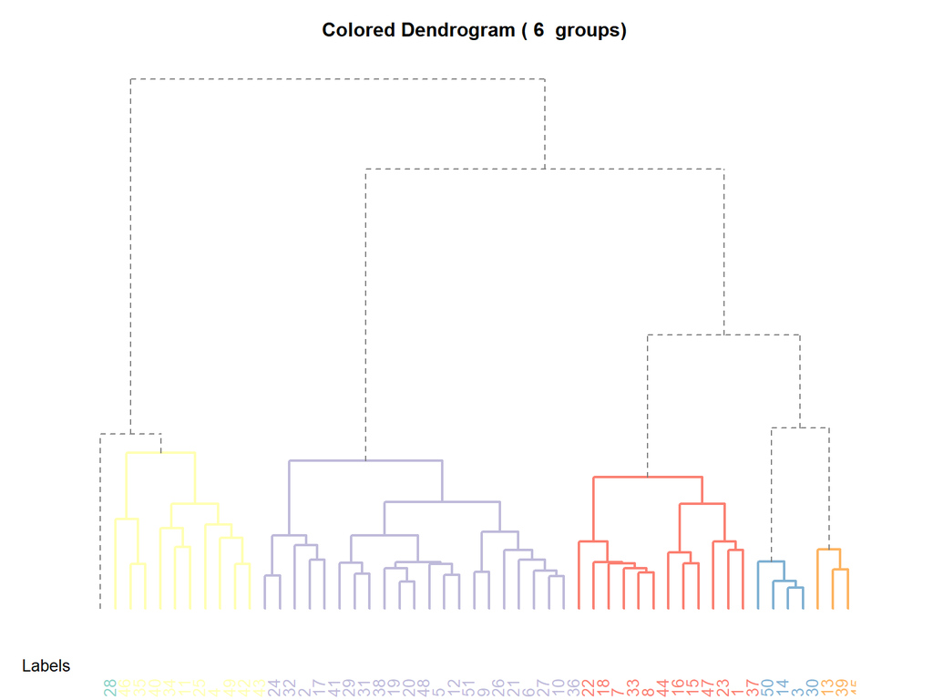

```r
source("http://addictedtor.free.fr/packages/A2R/lastVersion/R/code.R")

clusters=6

# colored dendrogram
op = par(bg = "white")
A2Rplot(clust2, k = clusters, boxes = FALSE, col.up = "gray50",
        col.down = RColorBrewer::brewer.pal(clusters, "Set3"))
```

Here, I just wanted to see how different the 2 clusters are.

The entanglement score is moderate, which means that the 2 hierarchical clusters are relatively similar

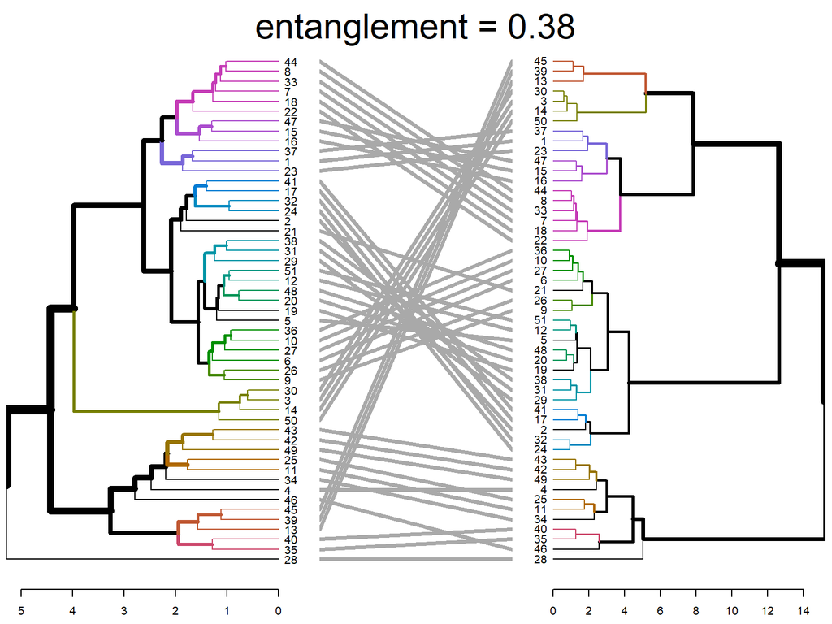

```r
dlist<-dendlist(as.dendrogram(clust1), as.dendrogram(clust2))
tanglegram(clust1, clust2,
  highlight_distinct_edges = FALSE, # Turn-off dashed lines
  common_subtrees_color_lines = FALSE, # Turn-off line colors
  common_subtrees_color_branches = TRUE, # Color common branches
  main = paste("entanglement =", round(entanglement(dlist), 2)
  ))
```

### Weighted Dissimilarity Score

Another potential factor that may be important to consider is the fact that 4 out of the 10 dimensions are assocaited with area, while the remaining 6 are associated with distance between each pair of categories. As such, it would be worth examining a hierarchical cluster with a more equal weight.

```r
df.w<-data.frame()
weights<-c(rep(1.5, 4), rep(1,6))
for (i in 1:51){
  for (j in 1:51){
    euc1.w<-apply(perm[[j]][,-1], 1, function(x) sqrt(sum((x-orig[i,-1])^2*weights)))
    euc2.w<-apply(perm[[i]][,-1], 1, function(x) sqrt(sum((x-orig[j,-1])^2*weights)))
    euc.w<-c(euc1.w, euc2.w)
    df.w[i,j]<-min(euc.w)
    # df2<-df[1:i, i]<-NA
  }
}

dist.w_mat<-as.dist(df.w)
```

Once again, “Ward.D2” seemed to be the best method out of all the ones I tried.

```r
ac2 <- function(x) {
  coef.hclust(hclust(dist.w_mat, method = x))
}
Coef2<-NULL
for (i in 1:length(m)){
  AC<-ac2(m[i])
  Coef2<-c(Coef2, AC)
}

names(Coef2)<-m
Coef2
```

```
##   ward.D2    single  complete   average  mcquitty
## 0.9226627 0.5998179 0.8207283 0.7270261 0.7306706
```

The dendrogram with minimized variance:

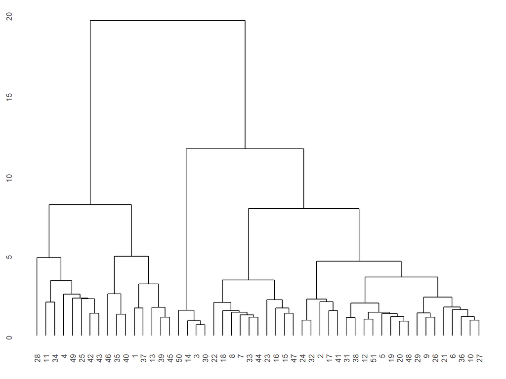

```r
clust2.w<-hclust(dist.w_mat, method="ward.D2")
ggdendrogram(clust2.w)
```

### Determining Optimal Number of Clusters

Although we have produced a structure of the hierarchical cluster, we still need to figure out what actually is the optimatl number of clusters. That is, at what point are clusters considered “distinct enough” from one another?

#### Determining the optimal number of clusters

```r
NbClust::NbClust(data=NULL, diss=dist.w_mat, distance=NULL, min.nc=2, max.nc=15, method="ward.D2", index="silhouette")
```

```
##
##  Only frey, mcclain, cindex, sihouette and dunn can be computed. To compute the other indices, data matrix is needed
```

```
## $All.index
##      2      3      4      5      6      7      8      9     10     11
## 0.4091 0.4004 0.3789 0.2865 0.2859 0.3096 0.2751 0.2387 0.2342 0.2353
##     12     13     14     15
## 0.2352 0.2498 0.2647 0.2575
##
## $Best.nc
## Number_clusters     Value_Index
##          2.0000          0.4091
##
## $Best.partition
##  1  2  3  4  5  6  7  8  9 10 11 12 13 14 15 16 17 18 19 20 21 22 23 24 25
##  1  2  2  1  2  2  2  2  2  2  1  2  1  2  2  2  2  2  2  2  2  2  2  2  1
## 26 27 28 29 30 31 32 33 34 35 36 37 38 39 40 41 42 43 44 45 46 47 48 49 50
##  2  2  1  2  2  2  2  2  1  1  2  1  2  1  1  2  1  1  2  1  1  2  2  1  2
## 51
##  2
```

#### Determining Maximum Number of Distinct Clusters

```r
k=15
method="ward.D2"
clust3<-hclust(dist.w_mat, method=method)

summ<-matrix(ncol = 2, nrow=k-1)
for (i in 2:k){
  cut<-cutree(clust3, i)
  sil_cl <- silhouette(cut ,dist_mat)
  sum.sil_cl<-summary(sil_cl)$ clus.avg.widths

  better<-NULL
  for (j in 1:10000){
    cut.rand<-sample(cut)
    names(cut.rand)<-c(1:51)
    sil.wid<-summary(silhouette(cut.rand ,dist_mat))$clus.avg.widths
    compare<-unname(ifelse(sil.wid>sum.sil_cl, 1, 0))
    better<-rbind(better, compare)
  }
  summ[i-1,1]<-i
  summ[i-1,2]<-ifelse(any(colMeans(better)>0.05), "Yes", "No")
}

summ<-as.data.frame(summ)
names(summ)<-c("Clusters", "SimulatiedBetter?")
summ
```

```
##    Clusters SimulatiedBetter?
## 1         2                No
## 2         3                No
## 3         4                No
## 4         5                No
## 5         6               Yes
## 6         7               Yes
## 7         8               Yes
## 8         9               Yes
## 9        10                No
## 10       11               Yes
## 11       12               Yes
## 12       13               Yes
## 13       14               Yes
## 14       15               Yes
```

##### 5 Clusters

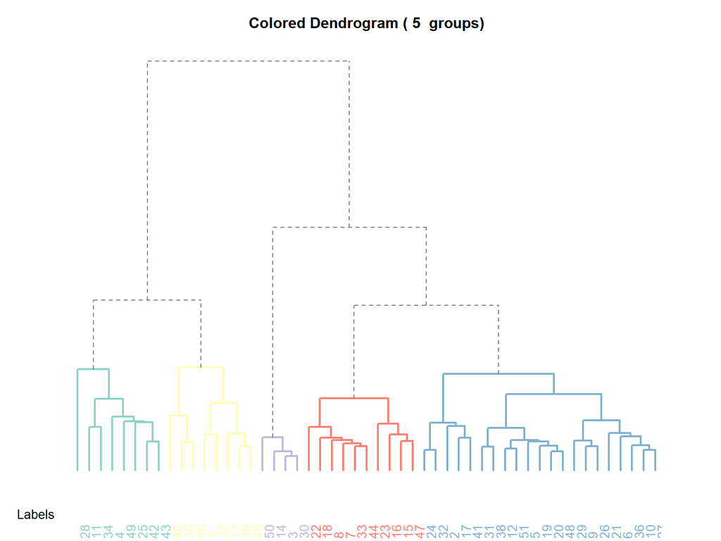

```r
source("http://addictedtor.free.fr/packages/A2R/lastVersion/R/code.R")

clusters=5

# colored dendrogram
op = par(bg = "white")
A2Rplot(clust3, k = clusters, boxes = FALSE, col.up = "gray50",
        col.down = RColorBrewer::brewer.pal(clusters, "Set3"))
```

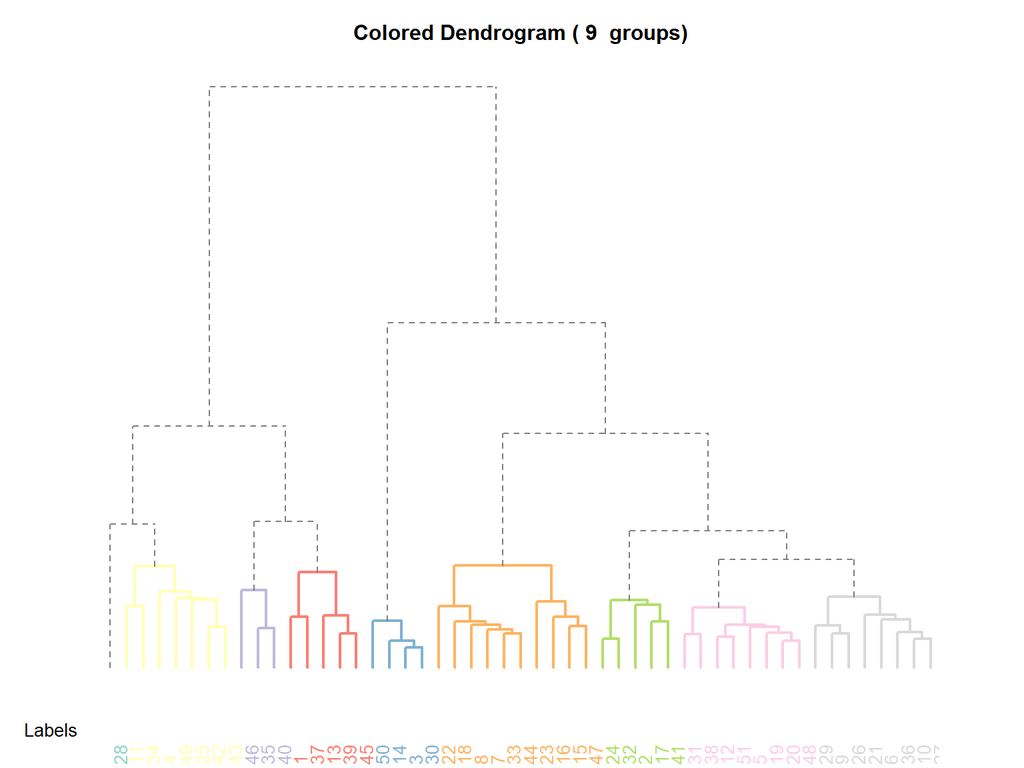

```r
source("http://addictedtor.free.fr/packages/A2R/lastVersion/R/code.R")

clusters=9

# colored dendrogram
op = par(bg = "white")
A2Rplot(clust3, k = clusters, boxes = FALSE, col.up = "gray50",
        col.down = RColorBrewer::brewer.pal(clusters, "Set3"))
```